# Summary

Mahathi Allepally

8/19/2021

# Project details

The purpose of this project is to analyze the different demographic breakdowns within arts commission grants awarded by the City of San Francisco. I chose to use the “San Francisco Arts Commission Grants FY2004-2016” data set from datasf.org.

## The data set

The data set is a data frame with 18 columns and 1942 rows of information. The columns that I will be focusing on are the grant amount, grant category and the various demographics of the artists and organizations that are receiving the grants, identified as “community focuses” in the data set.

Much of the data is categorical, with only the grant amount being numerical.

First I will read in the data.

```r
data <- read.csv("San_Francisco_Arts_Commission_Grants_FY2004-2016.csv")
```

Here I am checking what the set looks like.

```r
print(is.data.frame(data))
```

```
## [1] TRUE
```

```r
print(ncol(data))
```

```
## [1] 18
```

```r
print(nrow(data))
```

```
## [1] 1942
```

## Exploring the data set

First, I wanted to see what grant categories existed, and how many grants were awarded per category.

```r
data %>%
  group_by(Grant.Category) %>%
  tally()
```

```
## # A tibble: 14 x 2
##    Grant.Category                                                 n
##    <chr>                                                      <int>
##  1 "Arts and Community Innovative Partnership (ACIP) "          144
##  2 "Arts for Neighborhood Vitality (ANV)"                       126
##  3 "Creative Space (CRSP)"                                      114
##  4 "Cultural Center"                                             82
##  5 "Cultural Equity Initiative-Level 1 (CEI_L1)"                198
##  6 "Cultural Equity Initiative-Level 2 (CEI_L2)"                 43
##  7 "Individual Artist Commission (IAC)"                         398
##  8 "Native American Arts & Cultural Traditions (NAACT)"          97
##  9 "Organization Project Grant (OPG)"                           618
## 10 "Project in Communities (PIC)"                                80
## 11 "SPECIAL"                                                      3
## 12 "Special Grant"                                               18
## 13 "Special Project Grants (SPG)"                                18
## 14 "WritersCorps Teaching Artist in Residence Grant (WCTAIR)"     3
```

Here is a breakdown of grant money awarded each year.

```r
year_amt <- data %>%
              group_by(Grant.Fiscal.Year) %>%
              summarize(Total = sum(Grant.Amount))
year_amt
```

```
## # A tibble: 13 x 2
##    Grant.Fiscal.Year        Total
##    <chr>                    <dbl>
##  1 01/01/2004 12:00:00 AM 3206647
##  2 01/01/2005 12:00:00 AM 3534614
##  3 01/01/2006 12:00:00 AM 3921538
##  4 01/01/2007 12:00:00 AM 4151273
##  5 01/01/2008 12:00:00 AM 4696093
##  6 01/01/2009 12:00:00 AM 4350810
##  7 01/01/2010 12:00:00 AM 4218272
##  8 01/01/2011 12:00:00 AM 4210853
##  9 01/01/2012 12:00:00 AM 3948490
## 10 01/01/2013 12:00:00 AM 3917472
## 11 01/01/2014 12:00:00 AM 4317202
## 12 01/01/2015 12:00:00 AM 4748037
## 13 01/01/2016 12:00:00 AM 6790431
```

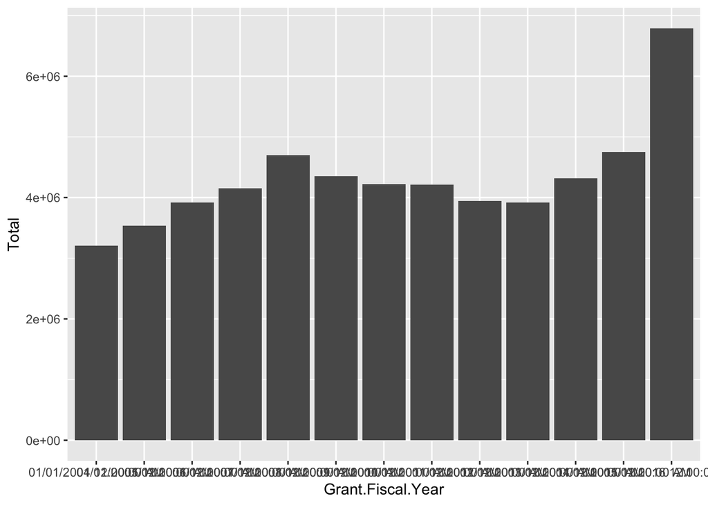

```r
ggplot(year_amt, mapping= aes(x=Grant.Fiscal.Year, y=Total)) +
  geom_bar(stat="identity")
```

Here is a plot showing the breakdown of each grant category for each fiscal year’s grants.

```r
year_cat <- data %>%
              group_by(Grant.Fiscal.Year) %>%
              count(Grant.Category)
year_cat
```

```
## # A tibble: 122 x 3
## # Groups:   Grant.Fiscal.Year [13]
##    Grant.Fiscal.Year      Grant.Category                                  n
##    <chr>                  <chr>                                       <int>
##  1 01/01/2004 12:00:00 AM Arts for Neighborhood Vitality (ANV)            8
##  2 01/01/2004 12:00:00 AM Creative Space (CRSP)                          10
##  3 01/01/2004 12:00:00 AM Cultural Center                                 7
##  4 01/01/2004 12:00:00 AM Cultural Equity Initiative-Level 1 (CEI_L1)    20
##  5 01/01/2004 12:00:00 AM Cultural Equity Initiative-Level 2 (CEI_L2)     3
##  6 01/01/2004 12:00:00 AM Individual Artist Commission (IAC)             14
##  7 01/01/2004 12:00:00 AM Organization Project Grant (OPG)               50
##  8 01/01/2004 12:00:00 AM Project in Communities (PIC)                   10
##  9 01/01/2004 12:00:00 AM Special Project Grants (SPG)                    8
## 10 01/01/2005 12:00:00 AM Arts for Neighborhood Vitality (ANV)            9
## # … with 112 more rows
```

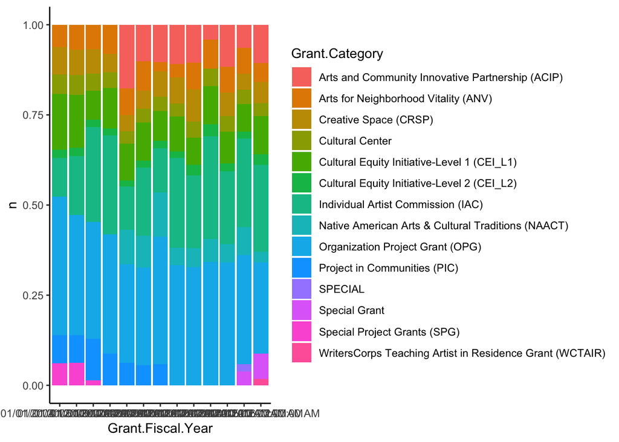

```r
ggplot(year_cat, aes(fill=Grant.Category, y=n, x=Grant.Fiscal.Year)) +
    geom_bar(position="fill", stat="identity")+theme_classic()
```

```r
#model <- lm(Community.Focus.Combined ~ Grant.Category, data = data)
#summary(model)$coef
```